# 第六次作业

冯裕祺

2021/5/17

# 1 公司雇员数据分析

本次作业搜集到了公司的雇员数据，通过对数据进行统计分析，通过探索性分析得到相关结果。

# 2 数据展示

首先对读入的数据进行大致分析。

```r
library(tidyverse)
data<-read.csv("Employee.csv",header = T)
rmarkdown::paged_table(data)
```

| 锘縤d | gender | bdate | educ | jobcat | salary | salbegin | jobtime | prevexp | minority |
| --- | --- | --- | --- | --- | --- | --- | --- | --- | --- |
| 1 | m | 2/3/52 | 15 | 3 | 57000 | 27000 | 98 | 144 | 0 |
| 2 | m | 5/23/58 | 16 | 1 | 40200 | 18750 | 98 | 36 | 0 |
| 3 | f | 7/26/29 | 12 | 1 | 21450 | 12000 | 98 | 381 | 0 |
| 4 | f | 4/15/47 | 8 | 1 | 21900 | 13200 | 98 | 190 | 0 |
| 5 | m | 2/9/55 | 15 | 1 | 45000 | 21000 | 98 | 138 | 0 |
| 6 | m | 8/22/58 | 15 | 1 | 32100 | 13500 | 98 | 67 | 0 |
| 7 | m | 4/26/56 | 15 | 1 | 36000 | 18750 | 98 | 114 | 0 |
| 8 | f | 5/6/66 | 12 | 1 | 21900 | 9750 | 98 | 0 | 0 |
| 9 | f | 1/23/46 | 15 | 1 | 27900 | 12750 | 98 | 115 | 0 |
| 10 | f | 2/13/46 | 12 | 1 | 24000 | 13500 | 98 | 244 | 0 |

[output cut: 464 more lines]

从上表我们可以看出，该数据共有9个变量，其中分类变量有性别（男性或者女性），是否是少数人种（是或者否），连续型变量有工资薪水，起始工资等，变量种类挺多需要进一步分析。

# 3 可视化分析探索

首先进行因子化处理。

```r
data$gender<-as.factor(data$gender)
data$minority<-as.factor(data$minority)
data$educ<-as.factor(data$educ)
data$jobcat<-as.factor(data$jobcat)
```

## 3.1 收入与性别分类箱线图

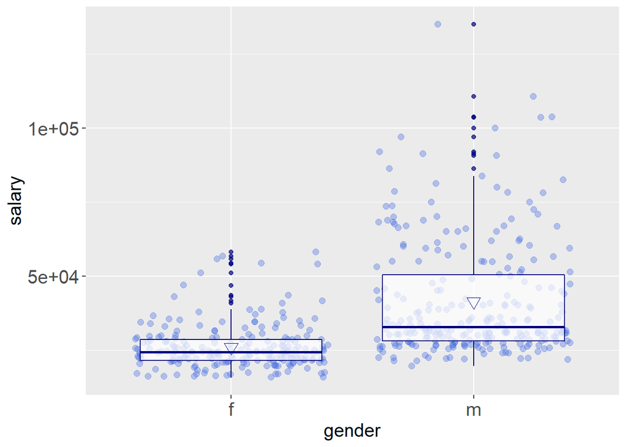

```r
ggplot(data = data,aes(x=gender,y=salary))+geom_jitter(alpha=.35,color='#4169E1',size=2.2)+geom_boxplot(alpha=.7,color='#000080')+stat_summary(fun.y="mean",geom="point",color="#000080",shape=6,size=3.5)+theme(axis.title.y=element_text(size=15))+theme(axis.title.x=element_text(size=15))+theme(axis.text.y=element_text(size=15))+theme(axis.text.x=element_text(size=15))
```

从收入与性别分类箱线图可以看出，男性的收入整体显著比女性高。女性收入较为集中，男性收入的分散程度大于女性。

## 3.2 收入与是否少数族裔箱线图

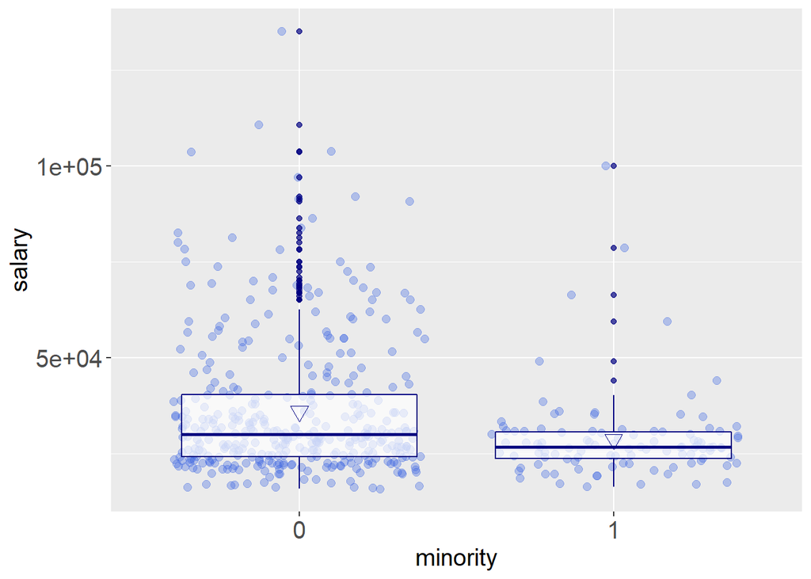

```r
ggplot(data = data,aes(x=minority,y=salary))+geom_jitter(alpha=.35,color='#4169E1',size=2.2)+geom_boxplot(alpha=.7,color='#000080')+stat_summary(fun.y="mean",geom="point",color="#000080",shape=6,size=3.5)+theme(axis.title.y=element_text(size=15))+theme(axis.title.x=element_text(size=15))+theme(axis.text.y=element_text(size=15))+theme(axis.text.x=element_text(size=15))
```

从收入与是否少数族裔图看出，非少数族裔的收入中位数与少数族裔的中位数的显著差别不大，但是非少数族裔的收入整体还是明显大于少数族裔的收入，说明在美国，少数族裔的收入是明显低于非少数族裔的。

## 3.3 收入与教育年限分类箱线图

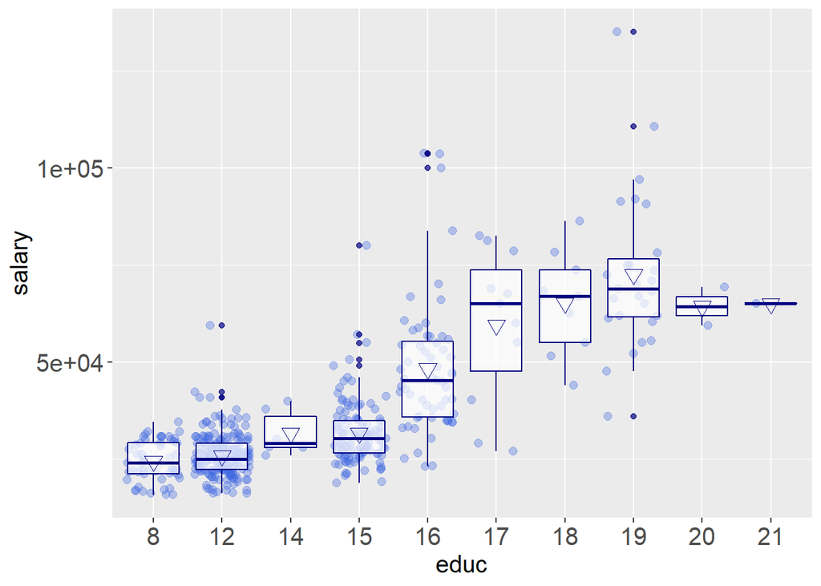

```r
ggplot(data = data,aes(x=educ,y=salary))+geom_jitter(alpha=.35,color='#4169E1',size=2.2)+geom_boxplot(alpha=.7,color='#000080')+stat_summary(fun.y="mean",geom="point",color="#000080",shape=6,size=3.5)+theme(axis.title.y=element_text(size=15))+theme(axis.title.x=element_text(size=15))+theme(axis.text.y=element_text(size=15))+theme(axis.text.x=element_text(size=15))
```

通过上图可以看出，受教育年限是明显的与收入大小成正比关系。在8和12这两个阶段相差不大，但是在16和17这两个阶段相差很大，一旦受教育程度从16提升到17，其收入程度会有很大的提升。并且随着年度的增加，这种边际效益会慢慢递减。

## 3.4 收入与职位等级分类箱线图

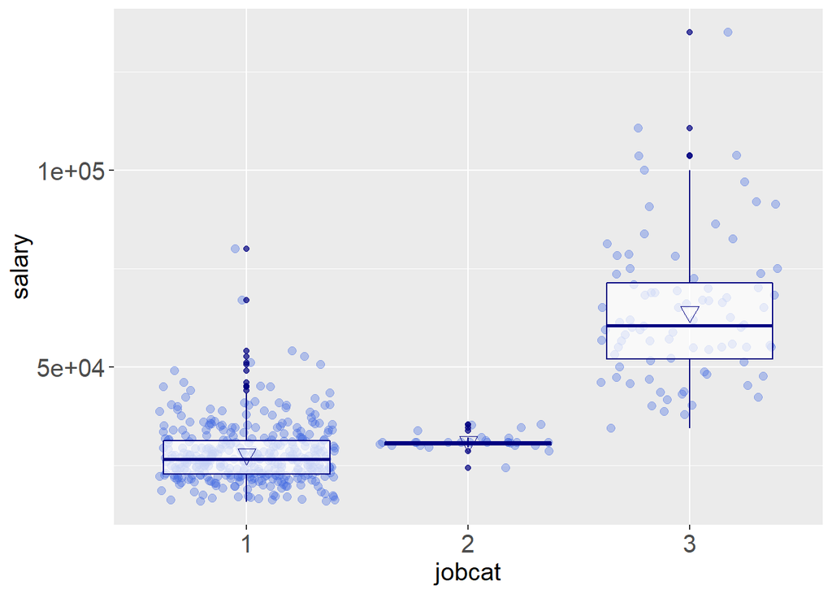

```r
ggplot(data = data,aes(x=jobcat,y=salary))+geom_jitter(alpha=.35,color='#4169E1',size=2.2)+geom_boxplot(alpha=.7,color='#000080')+stat_summary(fun.y="mean",geom="point",color="#000080",shape=6,size=3.5)+theme(axis.title.y=element_text(size=15))+theme(axis.title.x=element_text(size=15))+theme(axis.text.y=element_text(size=15))+theme(axis.text.x=element_text(size=15))
```

通过上图看出，职位等级的不同会明显提升收入水平，而在第二等级的数据十分紧密，初步推测是由于样本太小导致的，对数据中的jobcat进行计数分析如下。

```r
knitr::kable(data%>%count(jobcat))
```

| jobcat | n |
| --- | --- |
| 1 | 363 |
| 2 | 27 |
| 3 | 84 |

从上图看出，位于第二等级的样本明显小于其他两个等级，所以导致箱线图过于紧密。

## 3.5 受教育年限与性别关系

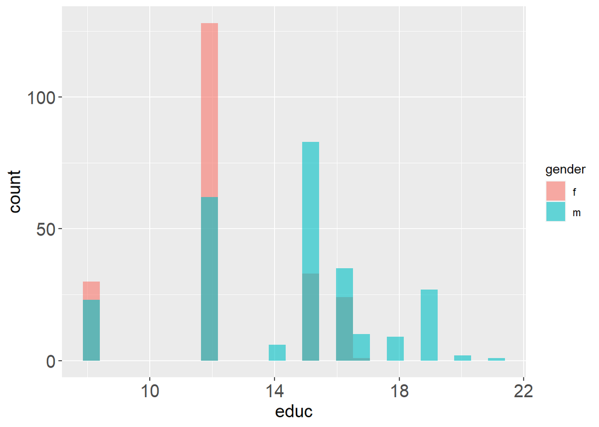

```r
data2<-read.csv("Employee.csv",header = T)#读取没有因子化的数据
ggplot(data2,aes(x=educ,fill=gender))+geom_histogram(position = "identity",alpha=0.6,bins = 25)+theme(axis.title.y=element_text(size=15))+theme(axis.title.x=element_text(size=15))+theme(axis.text.y=element_text(size=15))+theme(axis.text.x=element_text(size=15))
```

从上图看出，在搜集到的数据中，男性的受教育程度明显的多于女性，这也与受教育程度越高收入越高的事实相对应。

## 3.6 工作时间与性别关系图

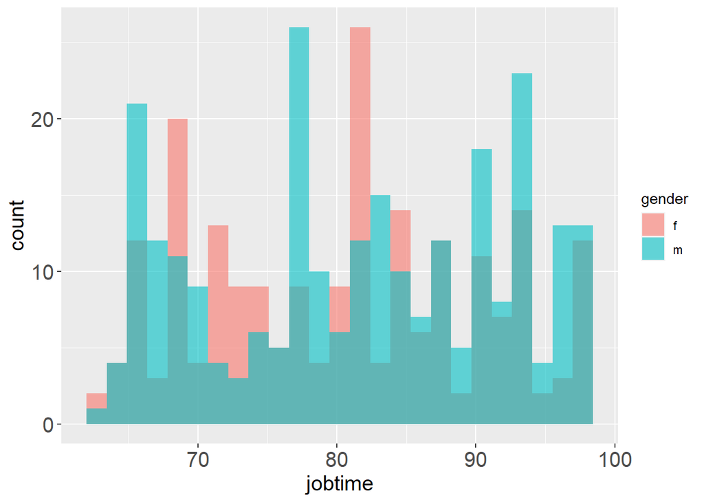

```r
ggplot(data2,aes(x=jobtime,fill=gender))+geom_histogram(position = "identity",alpha=0.6,bins = 25)+theme(axis.title.y=element_text(size=15))+theme(axis.title.x=element_text(size=15))+theme(axis.text.y=element_text(size=15))+theme(axis.text.x=element_text(size=15))
```

## 3.7 不同起始薪资与收入的关系

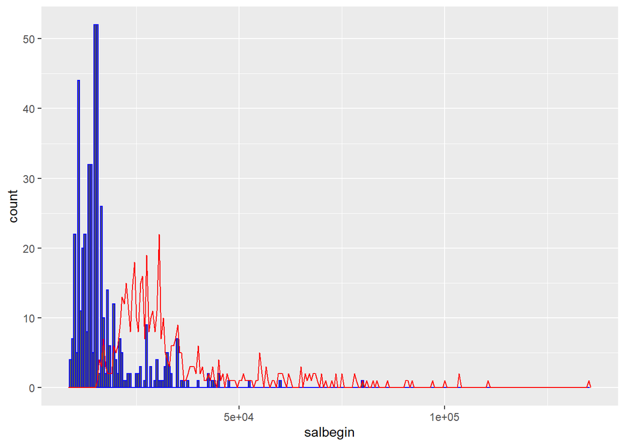

```r
ggplot(data = data2,aes(x = salbegin))+geom_histogram(binwidth = 500,color = "blue")+geom_freqpoly(mapping = aes(x=salary),binwidth = 500,color = "red")
```

上图纵轴是计数，横轴是起始薪资和当前薪资。直方图代表起始薪资，折线图代表现在的薪资。从上图看出，基本上当前的薪资都会比起始薪资高，并且数据都是在峰值左边较为聚集，在峰值右边明显的分散。

# 4 薪资数据建模分析。

通过之前的描述分析我们大致对数据有了初步的认识和判断，接着对数据进行建模分析。在这个问题中，薪资为因变量，自变量中含有因子类型的数据。首先使用传统的线性回归建立模型

```r
options(scipen = 200)
data3<-read.csv("Employee.csv",header = T)
data3$gender<-as.factor(data3$gender)#将性别转化为因子型
data3$minority<-as.factor(data3$minority)#将少数民族转化为因子型
model1<-lm(salary~educ+jobcat+salbegin+jobtime+prevexp+minority+gender,data=data3)
summary(model1)
```

```
##
## Call:
## lm(formula = salary ~ educ + jobcat + salbegin + jobtime + prevexp +
##     minority + gender, data = data3)
##
## Residuals:
##    Min     1Q Median     3Q    Max
## -22901  -3159   -744   2621  46291
##
## Coefficients:
##                 Estimate   Std. Error t value             Pr(>|t|)
## (Intercept) -13610.92441   3007.16431  -4.526       0.000007634730 ***
## educ           470.05170    153.56653   3.061              0.00233 **
## jobcat        5760.34182    621.45145   9.269 < 0.0000000000000002 ***
## salbegin         1.31956      0.07011  18.821 < 0.0000000000000002 ***
## jobtime        149.98267     31.32723   4.788       0.000002270406 ***
## prevexp        -20.94984      3.32098  -6.308       0.000000000656 ***
## minority1     -987.39645    784.18450  -1.259              0.20861
## genderm       2139.92620    735.59361   2.909              0.00380 **
## ---
## Signif. codes:  0 '***' 0.001 '**' 0.01 '*' 0.05 '.' 0.1 ' ' 1
##
## Residual standard error: 6805 on 466 degrees of freedom
## Multiple R-squared:  0.8435, Adjusted R-squared:  0.8412
## F-statistic: 358.9 on 7 and 466 DF,  p-value: < 0.00000000000000022
```

## 4.1 模型的检验

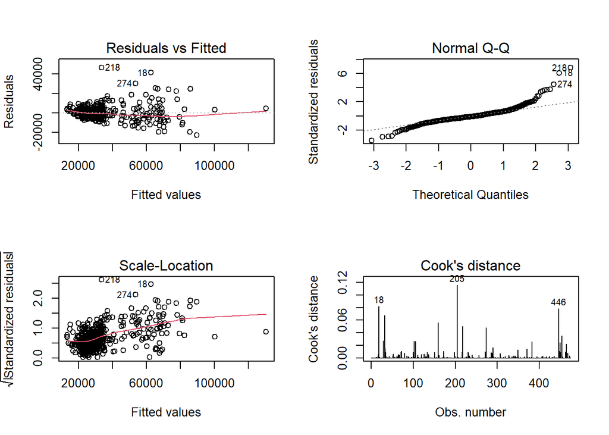

```r
par(mfrow=c(2,2))
plot(model1,which = c(1:4))
```

### 加权最小二乘建模 通过上面四张图看出该模型有一定的异方差性，需要进行加权建模。这里我们将权重设置为，salbegin,jobcat和jobtime三个变量的平方分之一，接着对模型进行分析。

```r
model2<-lm(salary~educ+jobcat+salbegin+jobtime+prevexp+gender,data=data3)
resd<-model2$residuals
resd<-abs(resd)
summary(model2)
```

```
##
## Call:
## lm(formula = salary ~ educ + jobcat + salbegin + jobtime + prevexp +
##     gender, data = data3)
##
## Residuals:
##    Min     1Q Median     3Q    Max
## -22924  -3272   -670   2606  46565
##
## Coefficients:
##                Estimate  Std. Error t value             Pr(>|t|)
## (Intercept) -13822.1833   3004.3615  -4.601       0.000005431508 ***
## educ           471.8788    153.6559   3.071              0.00226 **
## jobcat        5802.3314    620.9449   9.344 < 0.0000000000000002 ***
## salbegin         1.3284      0.0698  19.030 < 0.0000000000000002 ***
## jobtime        148.5239     31.3254   4.741       0.000002824209 ***
## prevexp        -21.4462      3.2996  -6.500       0.000000000207 ***
## genderm       2005.0468    728.2081   2.753              0.00613 **
## ---
## Signif. codes:  0 '***' 0.001 '**' 0.01 '*' 0.05 '.' 0.1 ' ' 1
##
## Residual standard error: 6809 on 467 degrees of freedom
## Multiple R-squared:  0.843,  Adjusted R-squared:  0.841
## F-statistic: 417.9 on 6 and 467 DF,  p-value: < 0.00000000000000022
```

```r
model3<-lm(salary~educ+jobcat+salbegin+jobtime+prevexp+gender,data=data3,weights = salbegin^{-2}+jobcat^{-2}+jobtime^{-2})
summary(model3)
```

```
##
## Call:
## lm(formula = salary ~ educ + jobcat + salbegin + jobtime + prevexp +
##     gender, data = data3, weights = salbegin^{
##     -2
## } + jobcat^{
##     -2
## } + jobtime^{
##     -2
## })
##
## Weighted Residuals:
##    Min     1Q Median     3Q    Max
## -14296  -2708   -642   2020  46853
##
## Coefficients:
##                 Estimate   Std. Error t value             Pr(>|t|)
## (Intercept) -12406.52132   2399.42065  -5.171    0.000000346681527 ***
## educ           446.91621    121.49125   3.679             0.000262 ***
## jobcat        5055.52805    886.57803   5.702    0.000000020991222 ***
## salbegin         1.45811      0.08887  16.407 < 0.0000000000000002 ***
## jobtime        121.53179     23.96567   5.071    0.000000571490307 ***
## prevexp        -18.95859      2.54655  -7.445    0.000000000000472 ***
## genderm       1511.88296    553.91437   2.729             0.006584 **
## ---
## Signif. codes:  0 '***' 0.001 '**' 0.01 '*' 0.05 '.' 0.1 ' ' 1
##
## Residual standard error: 4656 on 467 degrees of freedom
## Multiple R-squared:  0.717,  Adjusted R-squared:  0.7134
## F-statistic: 197.2 on 6 and 467 DF,  p-value: < 0.00000000000000022
```

```r
#计算model3残差
e<-resid(model3)
abse<-abs(e)
y.fit<-predict(model3)
biaozhunhua<-scale(e)
sqrtcancha<-sqrt(biaozhunhua)
```

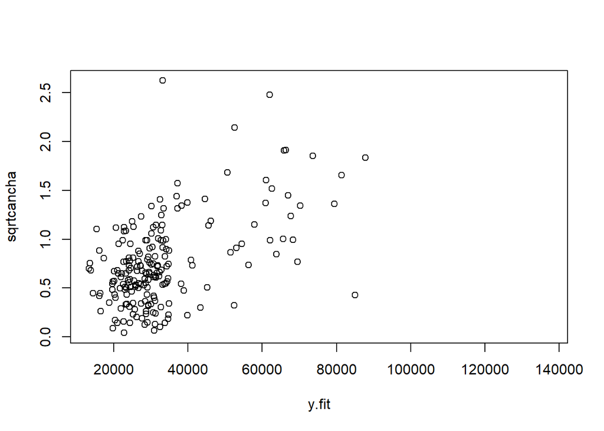

```r
plot(sqrtcancha~y.fit)
```

## 4.2 进行加权和未进行加权比较

### 4.2.1 未进行加权建模图

(

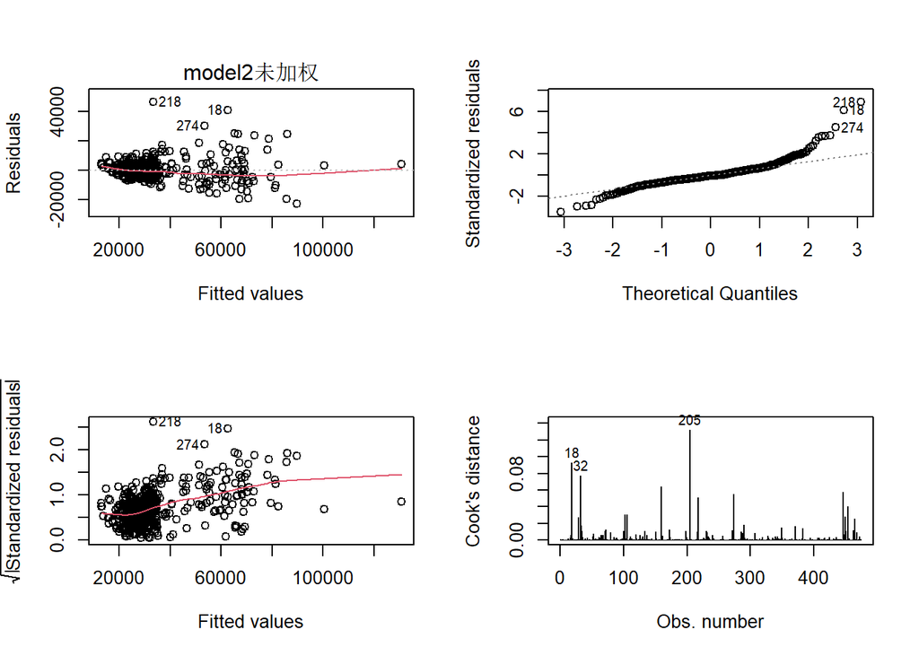

```r
par(mfrow=c(2,2))
plot(model2,which = c(1:4),caption = "model2未加权")
```

)

### 4.2.2 进行加权建模图

(

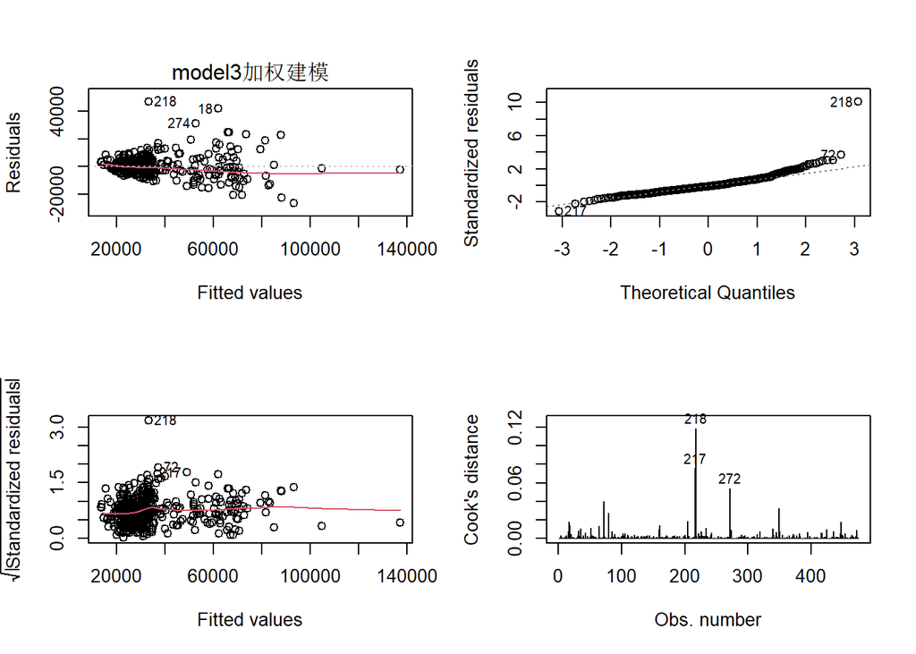

```r
par(mfrow=c(2,2))
plot(model3,which = c(1:4),caption = "model3加权建模")
```

)

通过上图看出,通过加权可以解决模型的异方差性。

## 4.3 检验多重共线性

```r
library(car)
round(vif(model3),2)
```

```
##     educ   jobcat salbegin  jobtime  prevexp   gender
##     1.53     1.54     2.32     1.02     1.11     1.33
```

上述变量都小于10并且接近1，说明没有多重共线性问题。

# 5 变量选择

在这里其实我感觉是不需要再进行变量选择的，因为模型已经解决了异方差性和多重共线性问题。但是课件上面讲了这些，还是做一下。

```r
modelstep<-step(model3,direction = "both")#使用逐步回归法
```

```
## Start:  AIC=8013.64
## salary ~ educ + jobcat + salbegin + jobtime + prevexp + gender
##
##            Df  Sum of Sq         RSS    AIC
## <none>                   10123086798 8013.6
## - gender    1  161490564 10284577362 8019.1
## - educ      1  293331236 10416418034 8025.2
## - jobtime   1  557438393 10680525190 8037.0
## - jobcat    1  704847552 10827934349 8043.5
## - prevexp   1 1201449131 11324535929 8064.8
## - salbegin  1 5835365806 15958452603 8227.4
```

```r
summary(modelstep)
```

```
##
## Call:
## lm(formula = salary ~ educ + jobcat + salbegin + jobtime + prevexp +
##     gender, data = data3, weights = salbegin^{
##     -2
## } + jobcat^{
##     -2
## } + jobtime^{
##     -2
## })
##
## Weighted Residuals:
##    Min     1Q Median     3Q    Max
## -14296  -2708   -642   2020  46853
##
## Coefficients:
##                 Estimate   Std. Error t value             Pr(>|t|)
## (Intercept) -12406.52132   2399.42065  -5.171    0.000000346681527 ***
## educ           446.91621    121.49125   3.679             0.000262 ***
## jobcat        5055.52805    886.57803   5.702    0.000000020991222 ***
## salbegin         1.45811      0.08887  16.407 < 0.0000000000000002 ***
## jobtime        121.53179     23.96567   5.071    0.000000571490307 ***
## prevexp        -18.95859      2.54655  -7.445    0.000000000000472 ***
## genderm       1511.88296    553.91437   2.729             0.006584 **
## ---
## Signif. codes:  0 '***' 0.001 '**' 0.01 '*' 0.05 '.' 0.1 ' ' 1
##
## Residual standard error: 4656 on 467 degrees of freedom
## Multiple R-squared:  0.717,  Adjusted R-squared:  0.7134
## F-statistic: 197.2 on 6 and 467 DF,  p-value: < 0.00000000000000022
```

上面是使用逐步回归法模型。其实可以使用这个来消除多重共线性等问题。

# 6 总结

通过各种方法，解决了异方差性和多重共线性，本文最终建立的模型如下：
$$salary=-12406.52+446.91*educ+5055.52*jobcat+1.45*salbegin+121.53*jobtime-18.95*prevexp+1511.88*gender$$